# Report

### Tables:

1. Pacients (Пациент)
2. PacientStats (Измерения показатилей пациента)
3. HospitalStats (Целевые переменные)

```python
import os

import pandas as pd
import numpy as np
import collections

import matplotlib.pyplot as plt
import seaborn as sns

from sqlalchemy import create_engine
```

```python
import warnings
warnings.filterwarnings('ignore')
```

## Formation table: HospitalStats

Формируем таблицу с целевыми переменными с полями:

1. RecordID - уникальный идентификационный номер пациента
2. Survival - целевая переменная, содержит информацию сколько дней прожил пациент после попадания в отделение интенсивной терапии (например, 575б 918, 5 и т. д.), -1 означает что пациент жив до сих пор.
3. In-hospital_death - целевая переменная, содержит информацию умер человек в отделение интенсивной терапии (1) или нет (0).

```python
outcomes = pd.read_csv('data/Outcomes.csv')
```

```python
outcomes.head()
```

|  | RecordID | Survival | In-hospital_death |
| --- | --- | --- | --- |
| 0 | 132539 | -1 | 0 |
| 1 | 132540 | -1 | 0 |
| 2 | 132541 | -1 | 0 |
| 3 | 132543 | 575 | 0 |
| 4 | 132545 | 918 | 0 |

```python
outcomes.nunique()
```

```
RecordID             8000
Survival             1003
In-hospital_death       2
dtype: int64
```

```python
outcomes.isnull().sum()
```

```
RecordID             0
Survival             0
In-hospital_death    0
dtype: int64
```

## Formation table: Pacients

У пациента будут поля:

1. RecordID - уникальный идентификационный номер пациента.
2. Age - возраст пациента в годах.
3. Gender - пол пациента (0: female, or 1: male).
4. Height - рост пациента в сантиметрах.
5. ICUType - тип отделения интенсивной терапии куда был доставлен пациент (1: Coronary Care Unit, 2: Cardiac Surgery Recovery Unit, 3: Medical ICU, or 4: Surgical ICU).
6. Weight - вес пациента в киллограммах (Обратите внимание, что вес является как общим дескриптором (записывается при поступлении), так и переменной временного ряда (часто измеряется ежечасно для оценки баланса жидкости)).

Меняем формат всех файлов в папке "data/set" с .txt на .csv

```python
for root, dirs, files in os.walk("./data/set"):
    for filename in files:
        base = os.path.splitext(filename)[0]
        os.rename(f'./data/set/{filename}', f'./data/set/{base}.csv')
```

```python
datas = {}
recordID_list = []

for root, dirs, files in os.walk("./data/set"):
    for filename in files:
        recordID = os.path.splitext(filename)[0]
        datas[recordID] = pd.read_csv(f'./data/set/{filename}')
        recordID_list.append(recordID)
```

```python
datas[recordID_list[0]]
```

|  | Time | Parameter | Value |
| --- | --- | --- | --- |
| 0 | 00:00 | RecordID | 132539.00 |
| 1 | 00:00 | Age | 54.00 |
| 2 | 00:00 | Gender | 0.00 |
| 3 | 00:00 | Height | -1.00 |
| 4 | 00:00 | ICUType | 4.00 |
| ... | ... | ... | ... |
| 268 | 47:37 | NIMAP | 79.33 |
| 269 | 47:37 | NISysABP | 128.00 |
| 270 | 47:37 | RespRate | 23.00 |
| 271 | 47:37 | Temp | 37.80 |
| 272 | 47:37 | Urine | 280.00 |

273 rows × 3 columns

```python
users_stats_df = [datas[idx] for idx in recordID_list]
params = pd.concat(users_stats_df, ignore_index=True)

params = list(params['Parameter'])
chart_data = dict(collections.Counter(params))

chart_data = pd.DataFrame([chart_data])
lim_up = max(chart_data.values.tolist()[0])
```

```python
main = {param: chart_data[param].iloc[0] for param in chart_data.columns if chart_data[param].iloc[0] == 8000}
main['Weight'] = 0
main = main.keys()
pd.DataFrame([{"Основные характеристики": h} for h in main])
```

|  | Основные характеристики |
| --- | --- |
| 0 | RecordID |
| 1 | Age |
| 2 | Gender |
| 3 | Height |
| 4 | ICUType |
| 5 | Weight |

```python
patients_cols = main
patients = pd.DataFrame(columns = patients_cols)
patients
```

|  | RecordID | Age | Gender | Height | ICUType | Weight |
| --- | --- | --- | --- | --- | --- | --- |

```python
for i, recordID in enumerate(recordID_list):
    if i < 1000:
        row = {}
        for col in patients_cols:
            row[col] = datas[recordID][datas[recordID]['Parameter'] == col]['Value'].values[-1:][0]
        patients = patients.append(pd.DataFrame([row]), ignore_index=True)
```

```python
patients
```

|  | RecordID | Age | Gender | Height | ICUType | Weight |
| --- | --- | --- | --- | --- | --- | --- |
| 0 | 132539.0 | 54.0 | 0.0 | -1.0 | 4.0 | -1.0 |
| 1 | 132540.0 | 76.0 | 1.0 | 175.3 | 2.0 | 81.6 |
| 2 | 132541.0 | 44.0 | 0.0 | -1.0 | 3.0 | 56.7 |
| 3 | 132543.0 | 68.0 | 1.0 | 180.3 | 3.0 | 84.6 |
| 4 | 132545.0 | 88.0 | 0.0 | -1.0 | 3.0 | -1.0 |
| ... | ... | ... | ... | ... | ... | ... |
| 995 | 135067.0 | 35.0 | 0.0 | -1.0 | 3.0 | 39.8 |
| 996 | 135069.0 | 73.0 | 1.0 | -1.0 | 3.0 | 104.0 |
| 997 | 135071.0 | 81.0 | 1.0 | -1.0 | 1.0 | 95.4 |
| 998 | 135072.0 | 63.0 | 1.0 | 172.7 | 2.0 | 77.7 |
| 999 | 135075.0 | 82.0 | 0.0 | 162.6 | 2.0 | 81.2 |

1000 rows × 6 columns

## Formation table: PacientStats

Таблица с показателями пациентов (по времени снятия показателей):

1. Albumin (g/dL).
2. ALP [Alkaline phosphatase (IU/L)].
3. ALT [Alanine transaminase (IU/L)].
4. AST [Aspartate transaminase (IU/L)].
5. Bilirubin (mg/dL).
6. BUN [Blood urea nitrogen (mg/dL)].
7. Cholesterol (mg/dL).
8. Creatinine [Serum creatinine (mg/dL)].
9. DiasABP [Invasive diastolic arterial blood pressure (mmHg)].
10. FiO2 [Fractional inspired O2 (0-1)].
11. GCS [Glasgow Coma Score (3-15)].
12. Glucose [Serum glucose (mg/dL)].
13. HCO3 [Serum bicarbonate (mmol/L)].
14. HCT [Hematocrit (%)].
15. HR [Heart rate (bpm)].
16. K [Serum potassium (mEq/L)].
17. Lactate (mmol/L).
18. Mg [Serum magnesium (mmol/L)].
19. MAP [Invasive mean arterial blood pressure (mmHg)].
20. MechVent [Mechanical ventilation respiration (0:false, or 1:true)].
21. Na [Serum sodium (mEq/L)].
22. NIDiasABP [Non-invasive diastolic arterial blood pressure (mmHg)].
23. NIMAP [Non-invasive mean arterial blood pressure (mmHg)].
24. NISysABP [Non-invasive systolic arterial blood pressure (mmHg)].
25. PaCO2 [partial pressure of arterial CO2 (mmHg)].
26. PaO2 [Partial pressure of arterial O2 (mmHg)].
27. pH [Arterial pH (0-14)].
28. Platelets (cells/nL).
29. RespRate [Respiration rate (bpm)].
30. SaO2 [O2 saturation in hemoglobin (%)].
31. SysABP [Invasive systolic arterial blood pressure (mmHg)].
32. Temp [Temperature (°C)].
33. TropI [Troponin-I (μg/L)].
34. TropT [Troponin-T (μg/L)].
35. Urine [Urine output (mL)].
36. WBC [White blood cell count (cells/nL)].
37. Weight (kg).

+

1. RecordID - индентификатор пациента
2. Time - время снятия показателей

Таски:

Общее кол-во значений по времянной шкале не равное 8000 (кол-ву пользователей)

параметры значения которых большее 20%

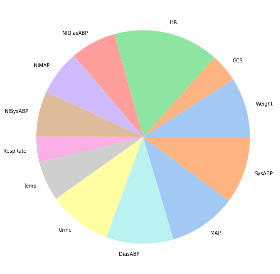

```python
cd_1 = {param: chart_data[param].iloc[0] for param in chart_data.columns
        if chart_data[param].iloc[0] > lim_up*0.2 and chart_data[param].iloc[0] != 1000}
cd = pd.DataFrame([cd_1])
colors = sns.color_palette('pastel')[:len(cd.iloc[0].values.tolist())]

plt.rcParams["figure.figsize"] = (10, 10)
plt.pie(cd.values.tolist()[0], labels=cd.columns, colors=colors)
plt.show()
```

параметры значание вхождений которых меньше 20%

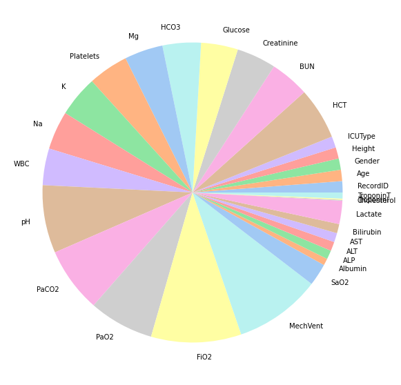

```python
cd_2 = {param: chart_data[param].iloc[0] for param in chart_data.columns
        if chart_data[param].iloc[0] < lim_up*0.2 and chart_data[param].iloc[0] != 1000}
cd = pd.DataFrame([cd_2])
color = sns.color_palette('pastel')[:len(cd.iloc[0].values.tolist())]

plt.rcParams["figure.figsize"] = (10, 10)
plt.pie(cd.values.tolist()[0], labels=cd.columns, colors=colors)
plt.show()
```

```python
cols_list = [col for col in {param: chart_data[param].iloc[0] for param in chart_data.columns if chart_data[param].iloc[0] != 8000}]
cols_list.extend(['RecordID', 'Time'])
cols_list
```

```
['Weight',
 'GCS',
 'HR',
 'NIDiasABP',
 'NIMAP',
 'NISysABP',
 'RespRate',
 'Temp',
 'Urine',
 'HCT',
 'BUN',
 'Creatinine',
 'Glucose',
 'HCO3',
 'Mg',
 'Platelets',
 'K',
 'Na',
 'WBC',
 'pH',
 'PaCO2',
 'PaO2',
 'DiasABP',
 'FiO2',
 'MAP',
 'MechVent',
 'SysABP',
 'SaO2',
 'Albumin',
 'ALP',
 'ALT',
 'AST',
 'Bilirubin',
 'Lactate',
 'Cholesterol',
 'TroponinI',
 'TroponinT',
 'RecordID',
 'Time']
```

```python
stats_patients = pd.DataFrame(columns=cols_list)
stats_patients
```

|  | Weight | GCS | HR | NIDiasABP | NIMAP | NISysABP | RespRate | Temp | Urine | HCT | ... | ALP | ALT | AST | Bilirubin | Lactate | Cholesterol | TroponinI | TroponinT | RecordID | Time |
| --- | --- | --- | --- | --- | --- | --- | --- | --- | --- | --- | --- | --- | --- | --- | --- | --- | --- | --- | --- | --- | --- |

0 rows × 39 columns

```python
from joblib import Parallel, delayed
from tqdm import tqdm
```

```python
stats_patients_list = []
datas_proba = {idx: datas[idx] for idx in list(datas.keys())[:1000]}
datas_proba
```

[output not shown]

[output cut: 14102 more lines]

```python
def processing(idx):
    new_patient = pd.DataFrame(columns=cols_list)
    times = datas_proba[idx]['Time'].unique()
    patient = datas_proba[idx]
    params = patient['Parameter'].unique()
    for time in times:
        new_data = {col: np.nan for col in cols_list}
        new_data['Time'] = time
        new_data['RecordID'] = idx
        for row in patient[patient['Time'] == time].values:
            if row[1] in cols_list and row[1] not in ['Time', 'RecordID']:
                new_data[row[1]] = row[2]
        new_patient = new_patient.append(pd.DataFrame([new_data]), ignore_index = True)
    stats_patients_list.append(new_patient)
    return new_patient

stats_patients_list = Parallel(n_jobs=-1, verbose=1000)(delayed(processing)(idx) for idx in datas_proba)
```

[output not shown]

[output cut: 930 more lines]

[output not shown]

```python
stats_patients = pd.concat(stats_patients_list, ignore_index=True)
stats_patients = stats_patients.fillna(stats_patients.median())
```

```python
def processing(idx, item):
    return int(item)

list_RecordID = Parallel(n_jobs=-1, verbose=1000)(delayed(processing)(idx, item) for idx, item in enumerate(stats_patients['RecordID'].values))
stats_patients['RecordID'] = list_RecordID
```

[output not shown]

[output cut: 442 more lines]

[output not shown]

```python
stats_patients['Hour'] = stats_patients['Time'].apply(lambda x: int(str(x).split(':')[0]))
stats_patients['Minute'] = stats_patients['Time'].apply(lambda x: int(str(x).split(':')[1]))
stats_patients = stats_patients.drop(['Time'], axis=1)
```

```python
stats_patients[stats_patients['RecordID'] == '132539'].head()
```

|  | Weight | GCS | HR | NIDiasABP | NIMAP | NISysABP | RespRate | Temp | Urine | HCT | ... | ALT | AST | Bilirubin | Lactate | Cholesterol | TroponinI | TroponinT | RecordID | Hour | Minute |
| --- | --- | --- | --- | --- | --- | --- | --- | --- | --- | --- | --- | --- | --- | --- | --- | --- | --- | --- | --- | --- | --- |

0 rows × 40 columns

```python
stats_patients.dtypes
```

```
Weight         float64
GCS            float64
HR             float64
NIDiasABP      float64
NIMAP          float64
NISysABP       float64
RespRate       float64
Temp           float64
Urine          float64
HCT            float64
BUN            float64
Creatinine     float64
Glucose        float64
HCO3           float64
Mg             float64
Platelets      float64
K              float64
Na             float64
WBC            float64
pH             float64
PaCO2          float64
PaO2           float64
DiasABP        float64
FiO2           float64
MAP            float64
MechVent       float64
SysABP         float64
SaO2           float64
Albumin        float64
ALP            float64
ALT            float64
AST            float64
Bilirubin      float64
Lactate        float64
Cholesterol    float64
TroponinI      float64
TroponinT      float64
RecordID         int64
Hour             int64
Minute           int64
dtype: object
```

# Формируем базу данных и отправляем туда данные

```python
engine = create_engine('sqlite:///db.sqlite')
```

```python
engine.execute("""
drop table if exists patients
""")
engine.execute("""
drop table if exists hospital_stats
""")
engine.execute("""
drop table if exists pacient_stats
""")
print("Clean db")
```

```
Clean db
```

### Создаем сущности

```python
engine.execute("""
create table if not exists patients (
    RecordID INTEGER PRIMARY KEY NOT NULL,
    Age INTEGER,
    Gender INTEGER,
    Height FLOAT,
    ICUType INTEGER,
    Weight FLOAT
);
""")

print("Create table 'patients'")
```

```
Create table 'patients'
```

```python
engine.execute("""
create table if not exists hospital_stats (
    RecordID INTEGER PRIMARY KEY NOT NULL,
    Survival FLOAT,
    In_hospital_death FLOAT
);
""")

print("Create table 'hospital_stats'")
```

```
Create table 'hospital_stats'
```

```python
engine.execute("""
create table if not exists pacient_stats (
    RecordID       INTEGER,
    Weight         FLOAT,
    GCS            FLOAT,
    HR             FLOAT,
    NIDiasABP      FLOAT,
    NIMAP          FLOAT,
    NISysABP       FLOAT,
    RespRate       FLOAT,
    Temp           FLOAT,
    Urine          FLOAT,
    HCT            FLOAT,
    BUN            FLOAT,
    Creatinine     FLOAT,
    Glucose        FLOAT,
    HCO3           FLOAT,
    Mg             FLOAT,
    Platelets      FLOAT,
    K              FLOAT,
    Na             FLOAT,
    WBC            FLOAT,
    pH             FLOAT,
    PaCO2          FLOAT,
    PaO2           FLOAT,
    DiasABP        FLOAT,
    FiO2           FLOAT,
    MAP            FLOAT,
    MechVent       FLOAT,
    SysABP         FLOAT,
    SaO2           FLOAT,
    Albumin        FLOAT,
    ALP            FLOAT,
    ALT            FLOAT,
    AST            FLOAT,
    Bilirubin      FLOAT,
    Lactate        FLOAT,
    Cholesterol    FLOAT,
    TroponinI      FLOAT,
    TroponinT      FLOAT,
    Hour           INT,
    Minute         INT
);
""")

print("Create table 'pacient_stats'")
```

```
Create table 'pacient_stats'
```

### Заполняем данными

> таблица patients

```python
table_name = 'patients'
columns_list = list(main)
columns_names = str(columns_list).replace('[', '').replace(']', '')
injections = str(['?' for i in columns_list]).replace('[', '').replace(']', '').replace("'", '')

for value in patients.values:
    engine.execute(
        f"INSERT INTO {table_name} ({columns_names}) VALUES ({injections})",
        [value]
    )
```

> таблица hospital_stats

```python
outcomes = outcomes.rename(columns={'In-hospital_death': 'In_hospital_death'})
outcomes = outcomes.dropna()
outcomes.head()
```

|  | RecordID | Survival | In_hospital_death |
| --- | --- | --- | --- |
| 0 | 132539 | -1 | 0 |
| 1 | 132540 | -1 | 0 |
| 2 | 132541 | -1 | 0 |
| 3 | 132543 | 575 | 0 |
| 4 | 132545 | 918 | 0 |

```python
outcomes['RecordID'] = outcomes['RecordID'].apply(lambda x: int(x))
outcomes['Survival'] = outcomes['Survival'].apply(lambda x: int(x))
outcomes['In_hospital_death'] = outcomes['In_hospital_death'].apply(lambda x: int(x))
```

```python
outcomes.dtypes
```

```
RecordID             int64
Survival             int64
In_hospital_death    int64
dtype: object
```

```python
table_name = 'hospital_stats'
columns_list = list(outcomes.columns)
columns_names = str(columns_list).replace('[', '').replace(']', '')
injections = str(['?' for i in columns_list]).replace('[', '').replace(']', '').replace("'", '')

for value in outcomes.values:
    value = list(value)
    for idx, item in enumerate(value):
        value[idx] = int(item)
    engine.execute(
        f"INSERT INTO {table_name} ({columns_names}) VALUES ({injections})",
        value
    )
```

> таблица pacient_stats

```python
table_name = 'pacient_stats'
columns_list = list(stats_patients.columns)
columns_names = str(columns_list).replace('[', '').replace(']', '')
injections = str(['?' for i in columns_list]).replace('[', '').replace(']', '').replace("'", '')

for value in stats_patients.values:
    engine.execute(
        f"INSERT INTO {table_name} ({columns_names}) VALUES ({injections})",
        [value]
    )
```

# Проверка базы

```python
engine.execute("""
    select * from patients
""").fetchall()[:10]
```

```
[(132539, 54, 0, -1.0, 4, -1.0),
 (132540, 76, 1, 175.3, 2, 81.6),
 (132541, 44, 0, -1.0, 3, 56.7),
 (132543, 68, 1, 180.3, 3, 84.6),
 (132545, 88, 0, -1.0, 3, -1.0),
 (132547, 64, 1, 180.3, 1, 114.0),
 (132548, 68, 0, 162.6, 3, 87.0),
 (132551, 78, 0, 162.6, 3, 48.4),
 (132554, 64, 0, -1.0, 3, 60.7),
 (132555, 74, 1, 175.3, 2, 69.7)]
```

```python
engine.execute("""
    select * from hospital_stats
""").fetchall()[:10]
```

```
[(132539, -1.0, 0.0),
 (132540, -1.0, 0.0),
 (132541, -1.0, 0.0),
 (132543, 575.0, 0.0),
 (132545, 918.0, 0.0),
 (132547, 1637.0, 0.0),
 (132548, -1.0, 0.0),
 (132551, 5.0, 1.0),
 (132554, 38.0, 0.0),
 (132555, -1.0, 0.0)]
```

```python
engine.execute("""
    select * from pacient_stats
""").fetchall()[:10]
```

```
[(132539, -1.0, 13.0, 86.0, 56.0, 74.67, 116.0, 19.0, 37.1, 65.0, 30.3, 21.0, 1.0, 127.0, 23.0, 2.0, 170.0, 4.1, 139.0, 11.3, 7.39, 39.0, 125.0, 58.0, 0.5, 77.0, 1.0, 116.0, 98.0, 2.9, 81.0, 40.0, 59.0, 0.9, 2.1, 154.0, 3.1500000000000004, 0.16, 0, 0),
 (132539, 80.5, 15.0, 73.0, 65.0, 92.33, 147.0, 19.0, 35.1, 900.0, 30.3, 21.0, 1.0, 127.0, 23.0, 2.0, 170.0, 4.1, 139.0, 11.3, 7.39, 39.0, 125.0, 58.0, 0.5, 77.0, 1.0, 116.0, 98.0, 2.9, 81.0, 40.0, 59.0, 0.9, 2.1, 154.0, 3.1500000000000004, 0.16, 0, 7),
 (132539, 80.5, 13.0, 77.0, 58.0, 91.0, 157.0, 19.0, 35.6, 60.0, 30.3, 21.0, 1.0, 127.0, 23.0, 2.0, 170.0, 4.1, 139.0, 11.3, 7.39, 39.0, 125.0, 58.0, 0.5, 77.0, 1.0, 116.0, 98.0, 2.9, 81.0, 40.0, 59.0, 0.9, 2.1, 154.0, 3.1500000000000004, 0.16, 0, 37),
 (132539, 80.5, 13.0, 60.0, 62.0, 87.0, 137.0, 18.0, 37.1, 30.0, 30.3, 21.0, 1.0, 127.0, 23.0, 2.0, 170.0, 4.1, 139.0, 11.3, 7.39, 39.0, 125.0, 58.0, 0.5, 77.0, 1.0, 116.0, 98.0, 2.9, 81.0, 40.0, 59.0, 0.9, 2.1, 154.0, 3.1500000000000004, 0.16, 1, 37),
 (132539, 80.5, 13.0, 62.0, 52.0, 75.67, 123.0, 19.0, 37.1, 170.0, 30.3, 21.0, 1.0, 127.0, 23.0, 2.0, 170.0, 4.1, 139.0, 11.3, 7.39, 39.0, 125.0, 58.0, 0.5, 77.0, 1.0, 116.0, 98.0, 2.9, 81.0, 40.0, 59.0, 0.9, 2.1, 154.0, 3.1500000000000004, 0.16, 2, 37),
 (132539, 80.5, 13.0, 86.0, 56.0, 74.67, 116.0, 19.0, 37.1, 65.0, 33.7, 21.0, 1.0, 127.0, 23.0, 2.0, 170.0, 4.1, 139.0, 11.3, 7.39, 39.0, 125.0, 58.0, 0.5, 77.0, 1.0, 116.0, 98.0, 2.9, 81.0, 40.0, 59.0, 0.9, 2.1, 154.0, 3.1500000000000004, 0.16, 3, 8),
 (132539, 80.5, 15.0, 80.0, 52.0, 72.67, 114.0, 20.0, 37.8, 60.0, 30.3, 21.0, 1.0, 127.0, 23.0, 2.0, 170.0, 4.1, 139.0, 11.3, 7.39, 39.0, 125.0, 58.0, 0.5, 77.0, 1.0, 116.0, 98.0, 2.9, 81.0, 40.0, 59.0, 0.9, 2.1, 154.0, 3.1500000000000004, 0.16, 3, 37),
 (132539, 80.5, 13.0, 74.0, 56.0, 74.67, 116.0, 20.0, 37.1, 65.0, 30.3, 21.0, 1.0, 127.0, 23.0, 2.0, 170.0, 4.1, 139.0, 11.3, 7.39, 39.0, 125.0, 58.0, 0.5, 77.0, 1.0, 116.0, 98.0, 2.9, 81.0, 40.0, 59.0, 0.9, 2.1, 154.0, 3.1500000000000004, 0.16, 4, 37),
 (132539, 80.5, 13.0, 73.0, 45.0, 66.67, 110.0, 17.0, 37.1, 170.0, 30.3, 21.0, 1.0, 127.0, 23.0, 2.0, 170.0, 4.1, 139.0, 11.3, 7.39, 39.0, 125.0, 58.0, 0.5, 77.0, 1.0, 116.0, 98.0, 2.9, 81.0, 40.0, 59.0, 0.9, 2.1, 154.0, 3.1500000000000004, 0.16, 5, 37),
 (132539, 80.5, 15.0, 64.0, 49.0, 68.33, 107.0, 15.0, 38.1, 120.0, 30.3, 21.0, 1.0, 127.0, 23.0, 2.0, 170.0, 4.1, 139.0, 11.3, 7.39, 39.0, 125.0, 58.0, 0.5, 77.0, 1.0, 116.0, 98.0, 2.9, 81.0, 40.0, 59.0, 0.9, 2.1, 154.0, 3.1500000000000004, 0.16, 7, 37)]
```